# Assignment2 - Plotting

Ethan T. Schmidt

September 17, 2018

This homework involves plotting and data manipulation. It requires the use of two new datasets, starwars and flights which live in the dplyr and nycflights13 packages respectively.

```r
library(dplyr)
library(ggplot2)
library(ggthemes)
theme_solarized_dark <- function() {
    theme_dark() +
        theme(
            plot.background = element_rect(fill = "#073642"),
            axis.text = element_text(color = '#eee8d5'),
            text = element_text(color = '#eee8d5'))
}
```

## Load the starwars dataset from the dplyr package.

```r
data(starwars)
starwars
```

```
## # A tibble: 87 x 13
##    name  height  mass hair_color skin_color eye_color birth_year gender
##    <chr>  <int> <dbl> <chr>      <chr>      <chr>          <dbl> <chr>
##  1 Luke~    172    77 blond      fair       blue            19   male
##  2 C-3PO    167    75 <NA>       gold       yellow         112   <NA>
##  3 R2-D2     96    32 <NA>       white, bl~ red             33   <NA>
##  4 Dart~    202   136 none       white      yellow          41.9 male
##  5 Leia~    150    49 brown      light      brown           19   female
##  6 Owen~    178   120 brown, gr~ light      blue            52   male
##  7 Beru~    165    75 brown      light      blue            47   female
##  8 R5-D4     97    32 <NA>       white, red red             NA   <NA>
##  9 Bigg~    183    84 black      light      brown           24   male
## 10 Obi-~    182    77 auburn, w~ fair       blue-gray       57   male
## # ... with 77 more rows, and 5 more variables: homeworld <chr>,
## #   species <chr>, films <list>, vehicles <list>, starships <list>
```

## Create a scatter plot of characters’ heights (x-axis) against their masses (y-axis). Be sure to label the axes and give the graph a title.

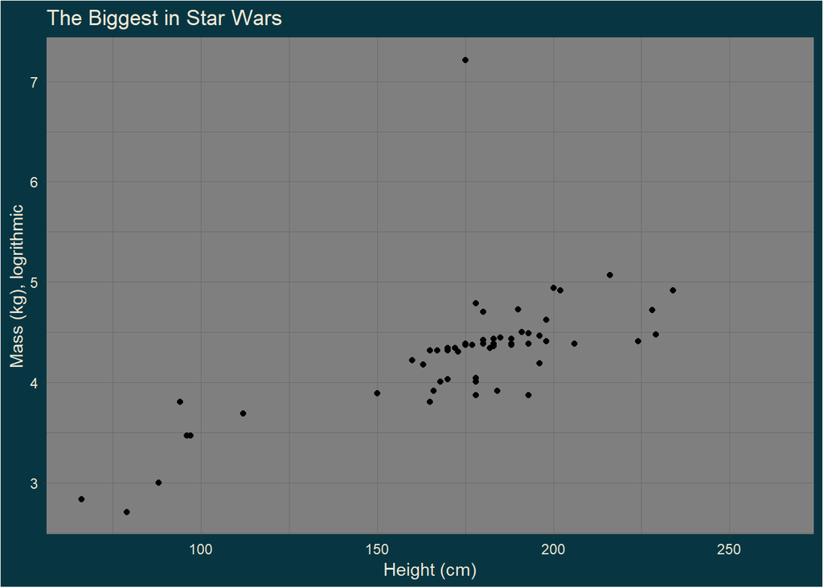

```r
ggplot(starwars, aes(x=height, y=log(mass))) +
    geom_point() +
    labs(x='Height (cm)', y='Mass (kg), logrithmic', title='The Biggest in Star Wars') +
    theme_solarized_dark()
```

## Create a histogram of birth year of starwars characters’ birth year.

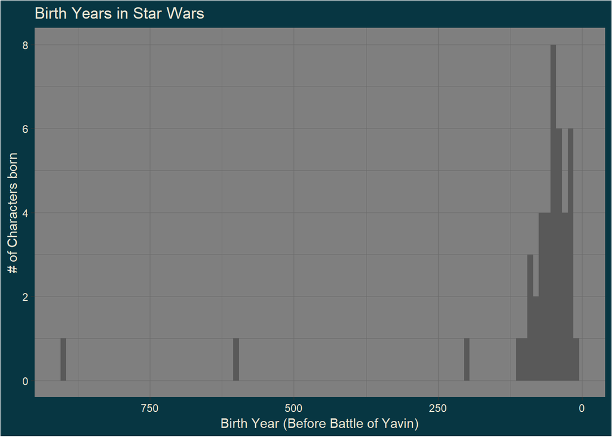

```r
ggplot(starwars, aes(x=birth_year)) +
    geom_histogram(binwidth = 10) +
    scale_x_reverse() +
    theme_solarized_dark() +
    labs(x='Birth Year (Before Battle of Yavin)', y='# of Characters born', title='Birth Years in Star Wars')
```

```r
starwars %>%
    filter(birth_year > 150)
```

```
## # A tibble: 3 x 13
##   name  height  mass hair_color skin_color eye_color birth_year gender
##   <chr>  <int> <dbl> <chr>      <chr>      <chr>          <dbl> <chr>
## 1 Chew~    228   112 brown      unknown    blue             200 male
## 2 Jabb~    175  1358 <NA>       green-tan~ orange           600 herma~
## 3 Yoda      66    17 white      green      brown            896 male
## # ... with 5 more variables: homeworld <chr>, species <chr>, films <list>,
## #   vehicles <list>, starships <list>
```

## Create density plots of heights faceted by gender. Change the ﬁll to something other than the default color, and use the theme theme_bw(). Be sure to let y-axis scales vary by gender.

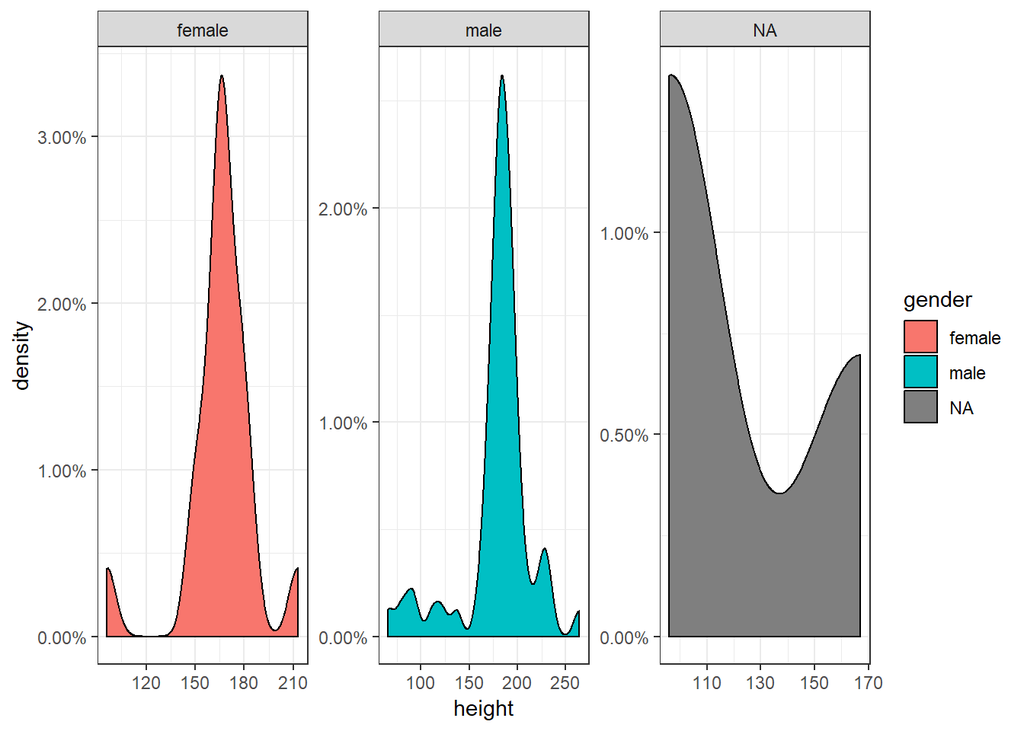

```r
starwars_gen <- starwars %>% filter(gender %in% c('female', 'male') | (is.na(gender)))
ggplot(starwars_gen, aes(x=height)) +
    geom_density(aes(fill=gender)) +
    scale_y_continuous(labels=scales::percent) +
    facet_wrap(~gender, scales = "free") +
    theme_bw()
```

## Create a violin plot of characters’ heights if they are of species type “Human”, “Droid”, “Wookiee”, or “Yoda’s species”. Use the economist theme in the ggthemes package.

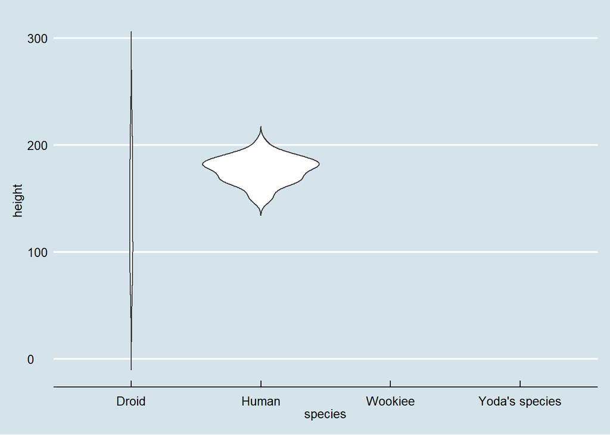

```r
starwars_spec <- starwars %>% filter(species %in% c('Human', "Droid", "Wookiee", "Yoda's species"))
ggplot(starwars_spec, aes(x=species, y=height)) +
    geom_violin(trim=FALSE, scale="count") +
    theme_economist()
```

## Use the contains function to select columns from the flights dataset in the nycflights13 package, that contain the word “dep”. Use starts_with to select columns that start with the letter “S”. Read Chapter 12 if you are uncertain about these functions.

```r
data(flights, package='nycflights13')
flights %>% select(contains('dep'), starts_with('s'))
```

```
## # A tibble: 336,776 x 4
##    dep_time sched_dep_time dep_delay sched_arr_time
##       <int>          <int>     <dbl>          <int>
##  1      517            515         2            819
##  2      533            529         4            830
##  3      542            540         2            850
##  4      544            545        -1           1022
##  5      554            600        -6            837
##  6      554            558        -4            728
##  7      555            600        -5            854
##  8      557            600        -3            723
##  9      557            600        -3            846
## 10      558            600        -2            745
## # ... with 336,766 more rows
```

## Calculate the mean and standard deviation of dep_delay, arr_delay, air_time and distance, for each origin, in the flights dataset. Be sure to account for missing (NA) values. Chapter 4 discusses ways to deal with NAs.

```r
flights %>%
    na.omit() %>%
    group_by(origin) %>%
    summarize(AvDepDel=mean(dep_delay), AvArDel=mean(arr_delay), AvAT=mean(air_time), AvDis=mean(distance))
```

```
## # A tibble: 3 x 5
##   origin AvDepDel AvArDel  AvAT AvDis
##   <chr>     <dbl>   <dbl> <dbl> <dbl>
## 1 EWR        15.0    9.11  153. 1065.
## 2 JFK        12.0    5.55  178. 1275.
## 3 LGA        10.3    5.78  118.  785.
```

## Use filter to return rows from the flights dataset that originate in JFK and depart in the afternoon.

```r
flights %>%
    filter(origin=='JFK' & 1800 > dep_time & dep_time > 1200)
```

```
## # A tibble: 39,165 x 19
##     year month   day dep_time sched_dep_time dep_delay arr_time
##    <int> <int> <int>    <int>          <int>     <dbl>    <int>
##  1  2013     1     1     1203           1200         3     1519
##  2  2013     1     1     1208           1158        10     1540
##  3  2013     1     1     1222           1229        -7     1520
##  4  2013     1     1     1237           1245        -8     1340
##  5  2013     1     1     1240           1235         5     1415
##  6  2013     1     1     1245           1245         0     1616
##  7  2013     1     1     1245           1249        -4     1722
##  8  2013     1     1     1246           1225        21     1424
##  9  2013     1     1     1251           1252        -1     1611
## 10  2013     1     1     1257           1258        -1     1601
## # ... with 39,155 more rows, and 12 more variables: sched_arr_time <int>,
## #   arr_delay <dbl>, carrier <chr>, flight <int>, tailnum <chr>,
## #   origin <chr>, dest <chr>, air_time <dbl>, distance <dbl>, hour <dbl>,
## #   minute <dbl>, time_hour <dttm>
```

```r
# after 6pm is the evening
```

## Create a new column in the flights dataset showing the average speed, calculated as distance divided by air_time. Name the column “AvgSpeed”. Use this column to calculate the average speed for flights departing each of the NYC airports.

```r
flights %>%
    na.omit() %>%
    mutate(AvgSpeed=distance/air_time) %>%
    group_by(origin) %>%
    summarize(AirportAvgSpeed=mean(AvgSpeed))
```

```
## # A tibble: 3 x 2
##   origin AirportAvgSpeed
##   <chr>            <dbl>
## 1 EWR               6.60
## 2 JFK               6.64
## 3 LGA               6.46
```